# report

### get data

```r
source("./get_data.R")
df_orig <- get_data()
```

```
## 2021-05-18 22:02:02 INFO::Reading data from disk
```

```r
source("./prepare_data.R")
df_orig <- prepare_data(df_orig)
```

```
## 2021-05-18 22:02:03 INFO::Imputing zeros in budget based on Random Forest
##   missForest iteration 1 in progress...done!
##   missForest iteration 2 in progress...done!
##   missForest iteration 3 in progress...done!
```

```r
comment(df_orig) <-  "Guardo el dataframe tras imputar valores faltantes, precision 21.9%"
saveRDS(df_orig, file = "./data/df_orig.rds")

df <- df_orig
nums <- df_orig %>% dplyr::select_if(is.numeric)
cats <- df_orig %>% dplyr::select_if(is.factor)
```

## Variable a optimizar

Queremos optimizar el beneficio obtenido al hacer una película. Para ello compararemos películas de distintas décadas, y hay que tener cuidado porque no es lo mismo un presupuesto o una recaudación de 30 millones en 1990, que 30 millones actuales. Esta variable tiende a aumentar por la inflación o el aumento de la poblanción mundial. Así pues, para poder comparar películas lejanas en el tiempo debemos neutralizar el efecto de esta tendencia. Abordaremos un aproximación simple que consiste en poner en relación Gross y Budget para obtener el beneficio neto. Otras aproximaciones podrían consistir en crear una serie temporal, descomponerla y eliminar la tendencia.

Observamos en los siguientes gráficos, que la tendencia constante al aumento se ha neutralizado, apareciendo otras tendencias que pueden responder a causas propias de la industria cinematográfica.

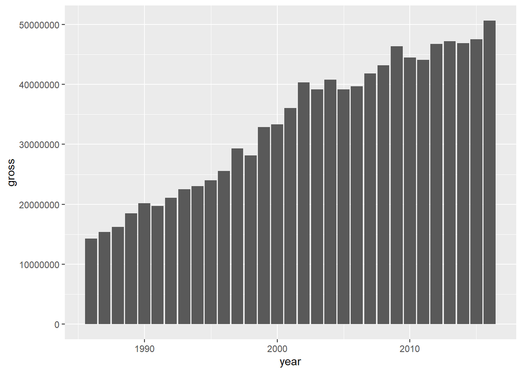

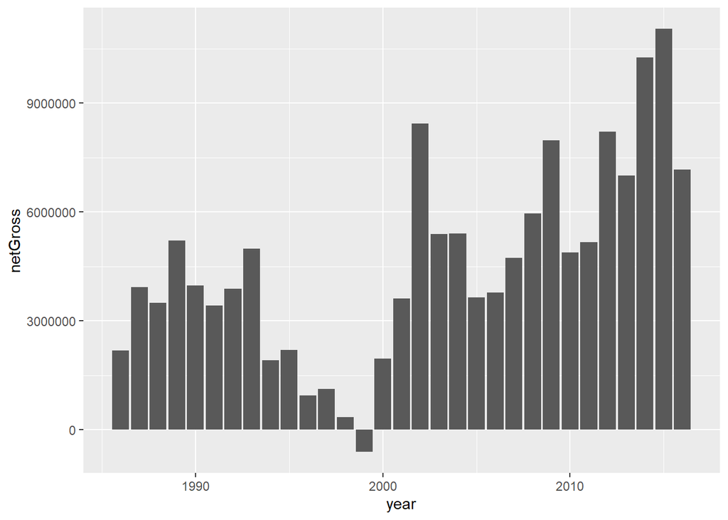

```r
f <- function(df, column) {
  p <- ggplot(df) +
  geom_bar(aes(year,.data[[column]]),
           position = "dodge", stat = "summary", fun = "mean")
  return(p)
}

plot_list <- lapply(list("gross", "netGross"), function(x){ f(nums, x) })
for (i in seq_along(plot_list)) print(plot_list[[i]])
```

## Qué variables explicativas debemos observar

Debemos prestar atención a las variables que podemos decidir antes de emprender la producción de una película. Otras como año, o score no podemos controlarlas.

## Preparación de datos

En la preparación de datos hemos hecho varias cosas:

En las variables genre, country y company hemos agrupado en “Other” todas las observaciones que aparecen poco, porque una productora que aparece 2 o 3 veces, sesga el análisis

De forma similar, hay algunos valores para rating que aparecen muy poco, así que los agrupo como UNRATED, así como otras entradas que significan lo mismo: NOT RATED y Not specified.

Dado que hay 2182 observaciones con presupuesto de película cero, hemos intentado imputar estos valores faltantes con varias técnicas de regresión. Para asegurarnos de la fiabilidad de estas imputaciones, previamente se han obtenido métricas de error, generando un 20% de nulos donde no los había, y comprobando el error de estas predicciones. Las métricas de error arrojadas por estas imputaciones rondan el 20-40% de error en RMSE.

### Estadísticas

Veamos estdísticas de cada variable numérica, y a continuación algunas de las variables categóricas.

|  | media | mediana | moda | Q1 | Q2 | Q3 | max | min |
| --- | --- | --- | --- | --- | --- | --- | --- | --- |
| budget | 28928280 | 16842625.0 | 20000000.0 | 9053928.5 | 16842625.0 | 33954333 | 300000000 | 6000 |
| gross | 33497829 | 12135679.0 | 3500000.0 | 1515839.0 | 12135679.0 | 40065341 | 936662225 | 70 |
| runtime | 107 | 102.0 | 100.0 | 95.0 | 102.0 | 115 | 366 | 50 |
| score | 6 | 6.4 | 6.7 | 5.8 | 6.4 | 7 | 9 | 2 |
| votes | 71220 | 25892.5 | 2003.0 | 7665.2 | 25892.5 | 75812 | 1861666 | 27 |
| year | 2001 | 2001.0 | 1989.0 | 1993.0 | 2001.0 | 2009 | 2016 | 1986 |
| grossPerBudget | 3 | 0.6 | 0.4 | 0.2 | 0.6 | 2 | 7195 | 0 |
| netGross | 4569549 | -4509306.0 | 2200000.0 | -11410306.8 | -4509306.0 | 8924619 | 691662225 | -176921900 |

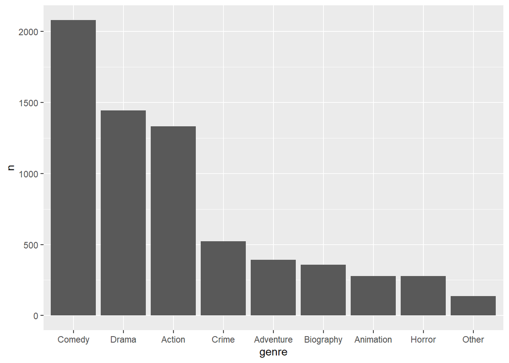

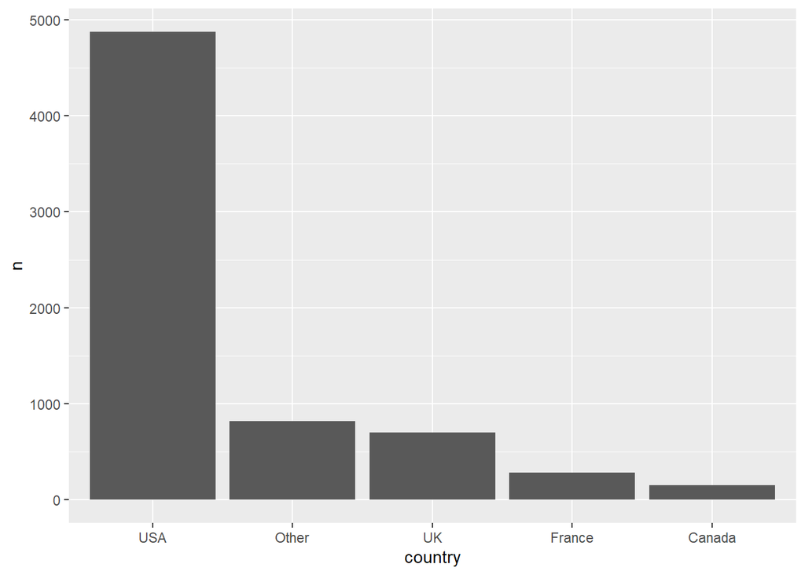

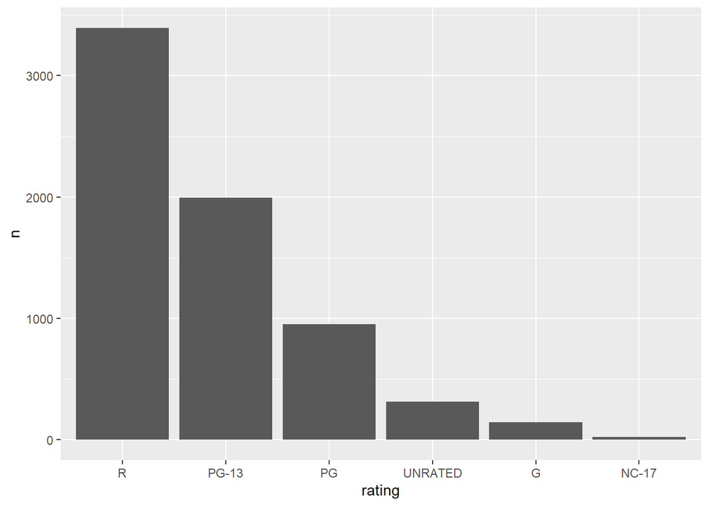

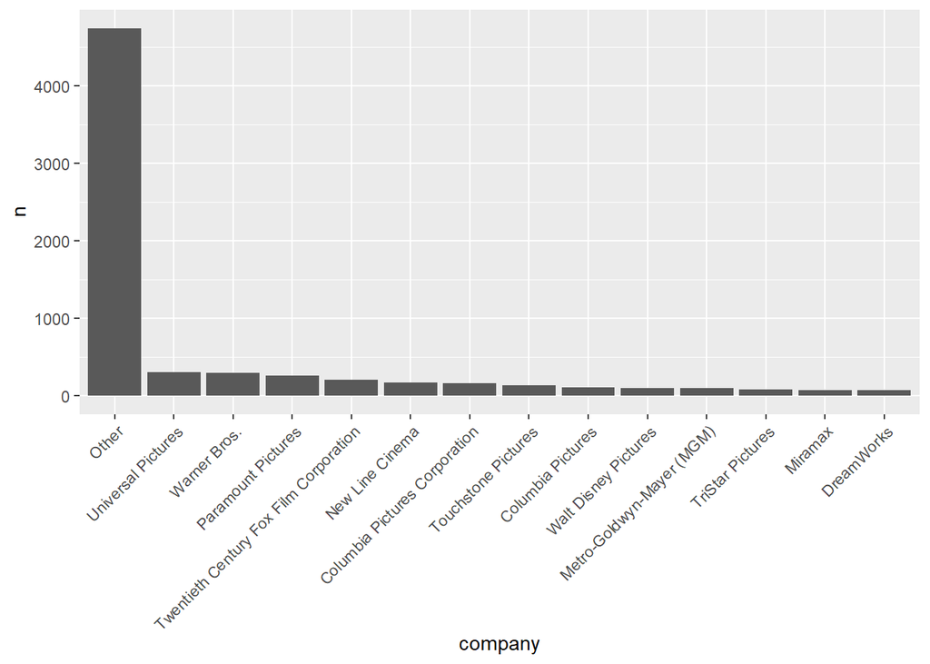

Se observa que company tiene demasiada granularidad para usarlo en el análisis. Además, carece de interés para el caso de uso, ya que no podemos decidir sobre ella. Si nosotros somos la productora “Martínez” no podríamos elegir ser Universal Pictures.

Veamos ahora el beneficio neto por país, por rating y por género. Ya podemos ir adelantando que las películas rentables son las americanas y luego lo confirmaremos con un análisis más detallado. Cabe señalar que en el género de terror sí hay películas rentables en otros países.

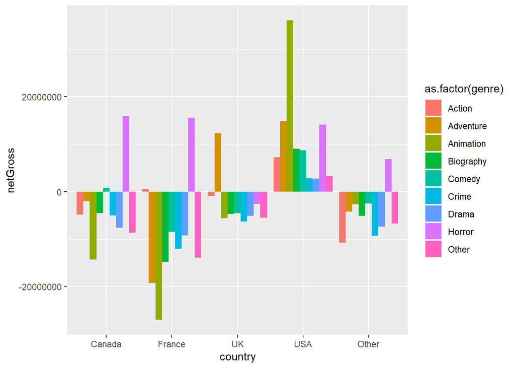

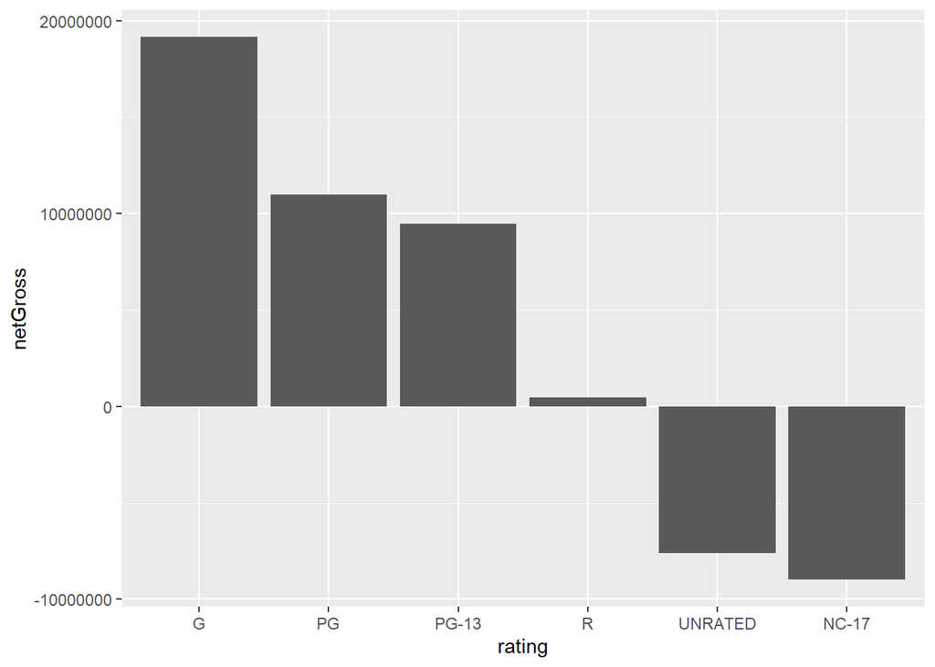

Ratings: Rated G: General audiences – All ages admitted.

Rated PG: Parental guidance suggested – Some material may not be suitable for pre-teenagers.

Rated PG-13: Parents Strongly Cautioned – Some material may be inappropriate for children under 13.

Rated R: Restricted – Under 17 requires accompanying parent or adult guardian.

Rated NC-17: No children under 17 admitted

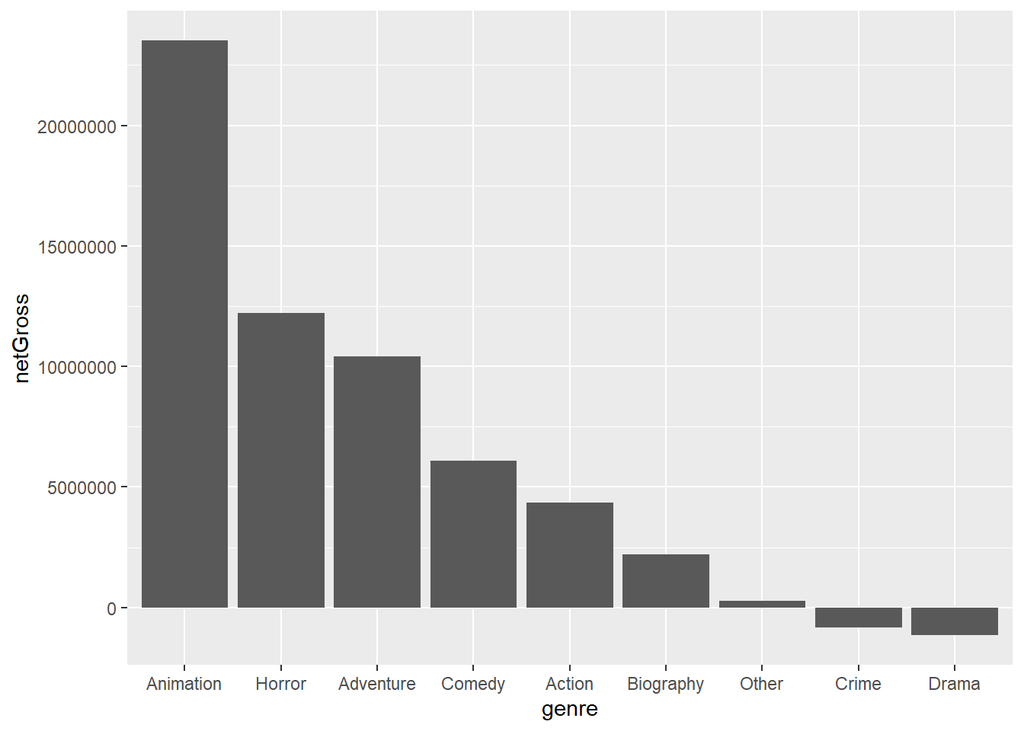

## Boxplots

El boxplot nos representa: la mediana (línea negra gruesa), el recorrido intercuartílico (Q1:Q3) (caja) y los “bigotes” (líneas superiores) que representan 1.5 veces el recorrido intercuartílico. Los puntos más allá de estas líneas son los valores atípicos (outliers). Sobre esta gráfica hemos añadido información adicional como la media (triángulo rojo).

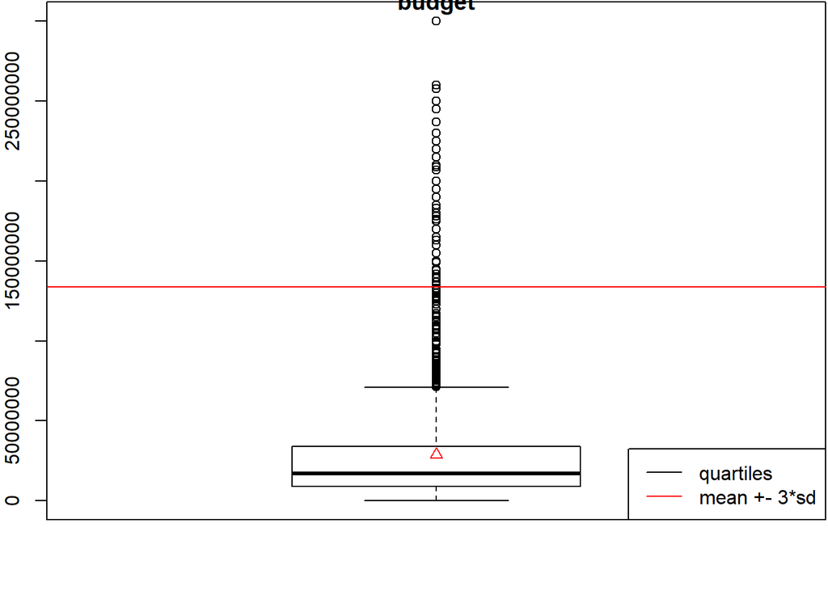

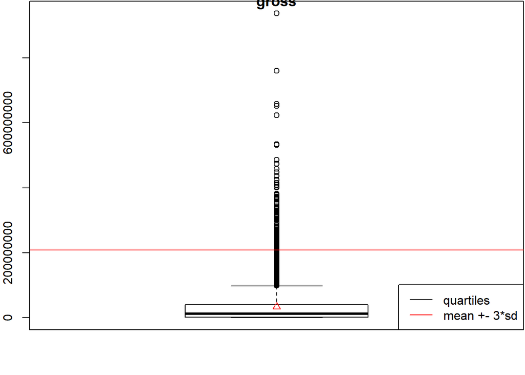

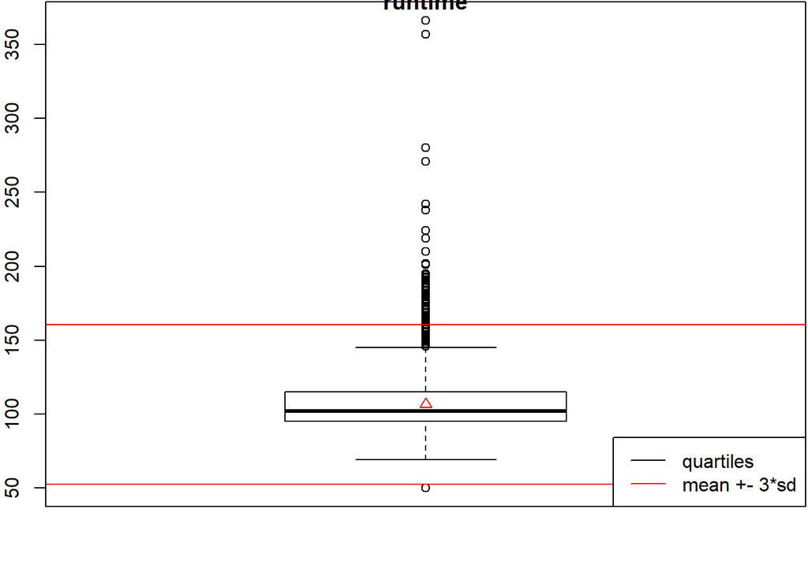

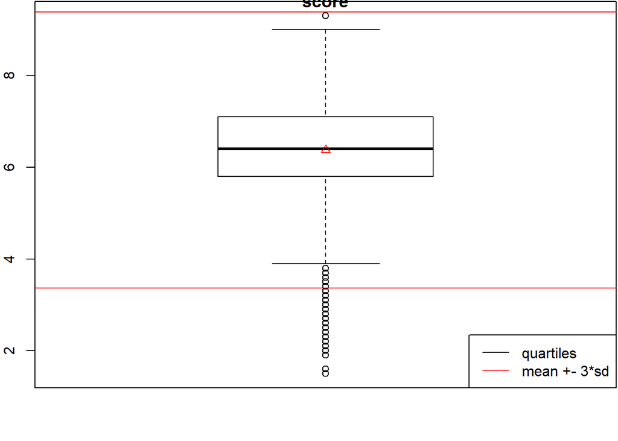

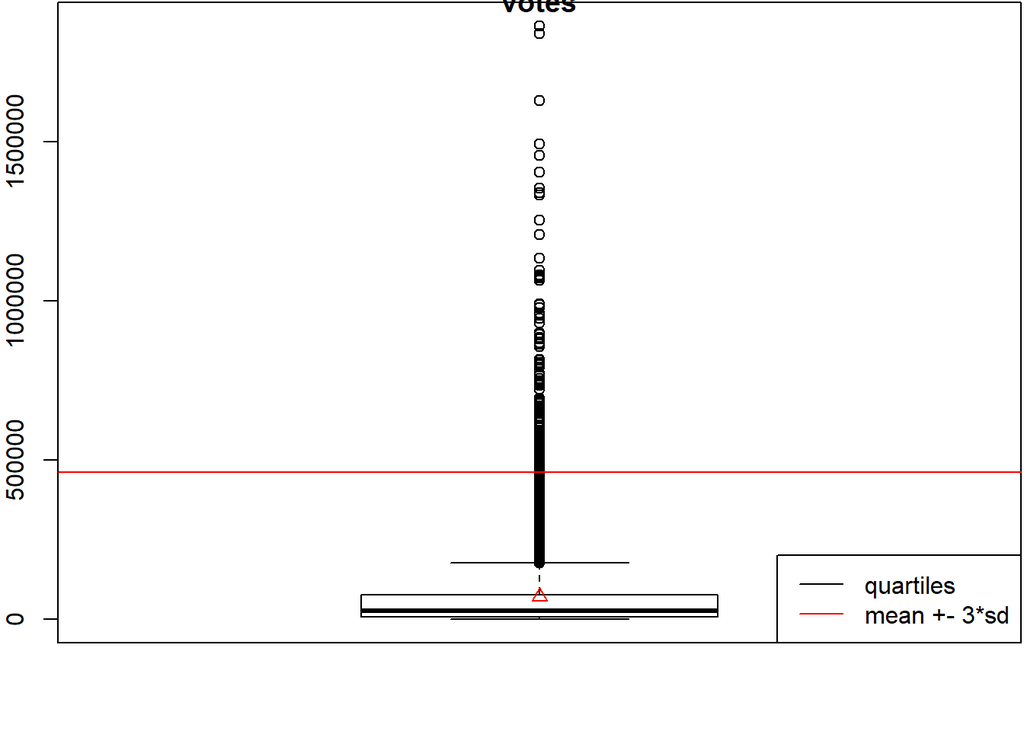

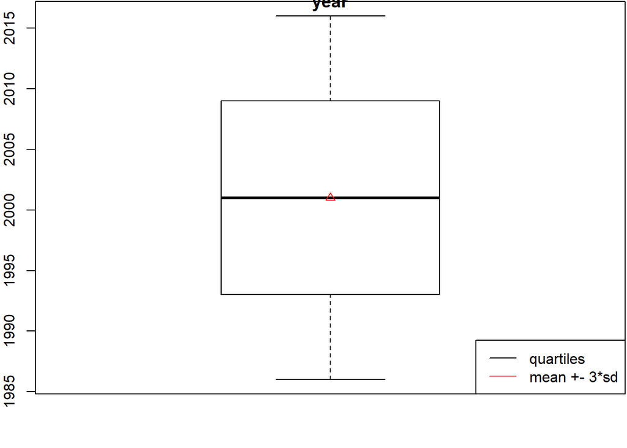

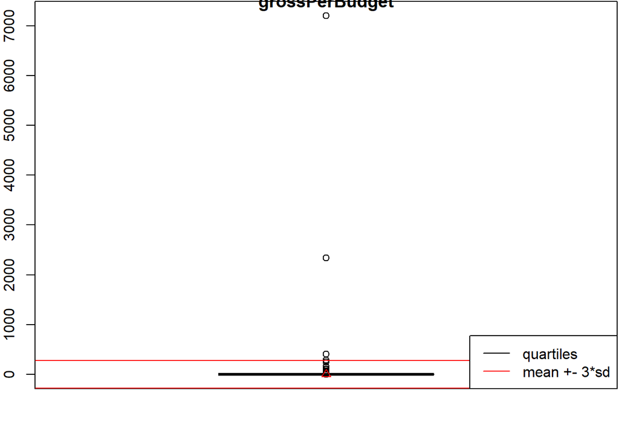

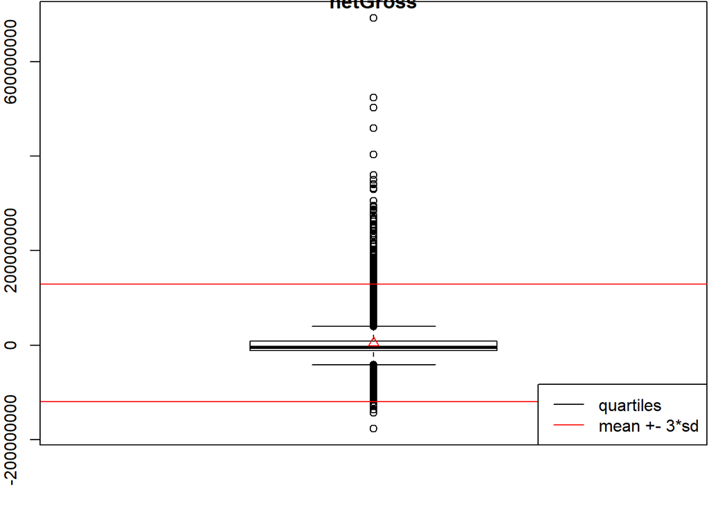

```r
# pdf("boxplots.pdf")
par(mar = c(3, 2, .1, .1))
for (i in colnames(nums)){
  X = nums[, i]
    boxplot(X, main=i)
    abline (h = mean(X) + 3 * sd(X), col = "red")
    points(mean(X), col = "red", pch = 2)
    abline (h = mean(X) - 3 * sd(X), col = "red")
    legend (x = "bottomright", col =c("black", "red"), lty = c(1, 1), legend = c("quartiles", "mean +- 3*sd"))
}
# dev.off()
```

Nos encontramos con varias distribuciones bastante sesgadas a la derecha, lo cual nos indica que quizá tengamos que hacer una transformación de las variables para ajustar correctamente un modelo predictivo. Además vemos que la variable grossPerBudget tiene unos outliers muy grandes. Si quisiéramos predecir esta variable, habría que tenerlo en cuenta. Y si hacemos visualizaciones con ella deberíamos eliminarlos.

Con los siguientes gráficos de densidad confirmamos la distribución sesgada a la derecha de gross y budget.

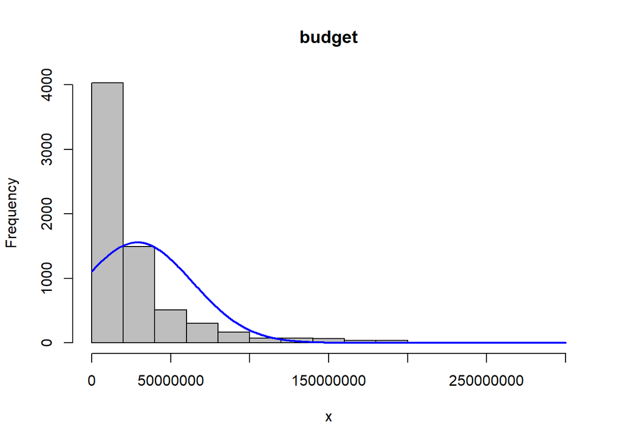

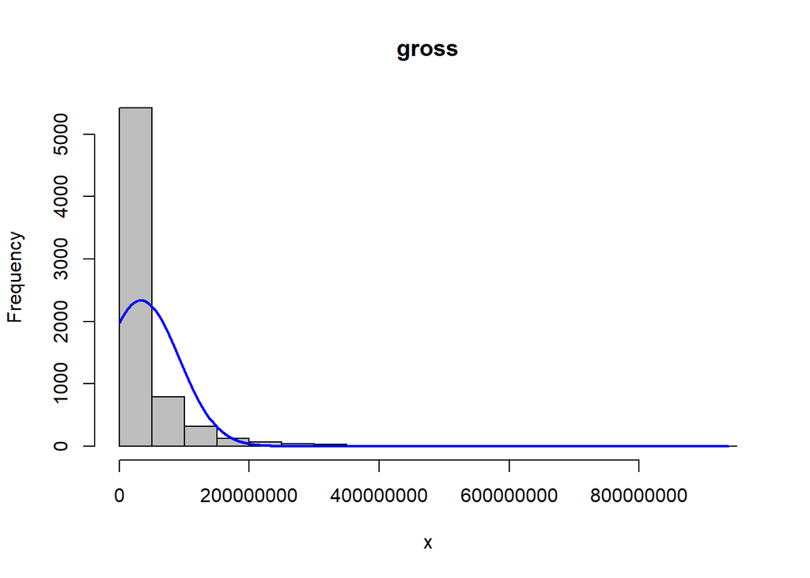

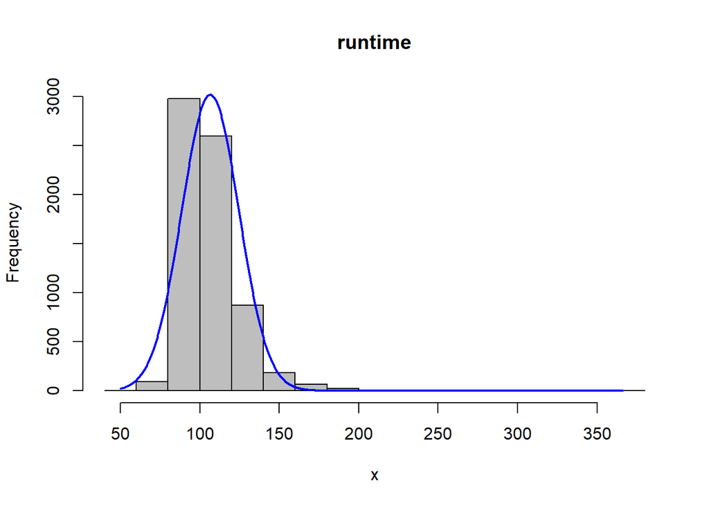

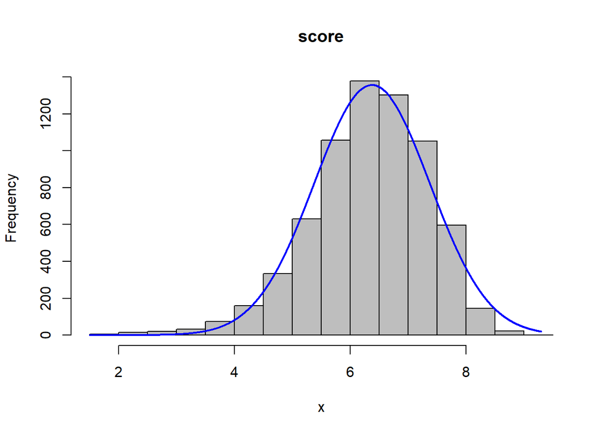

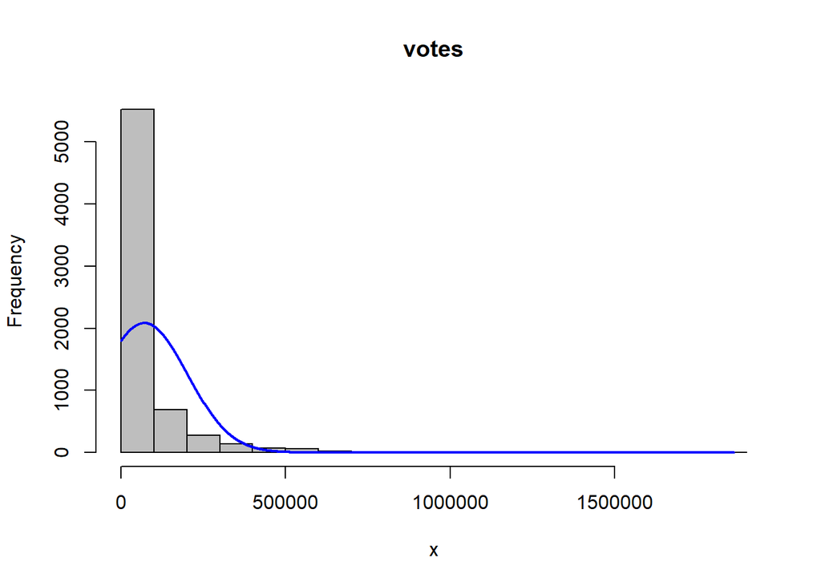

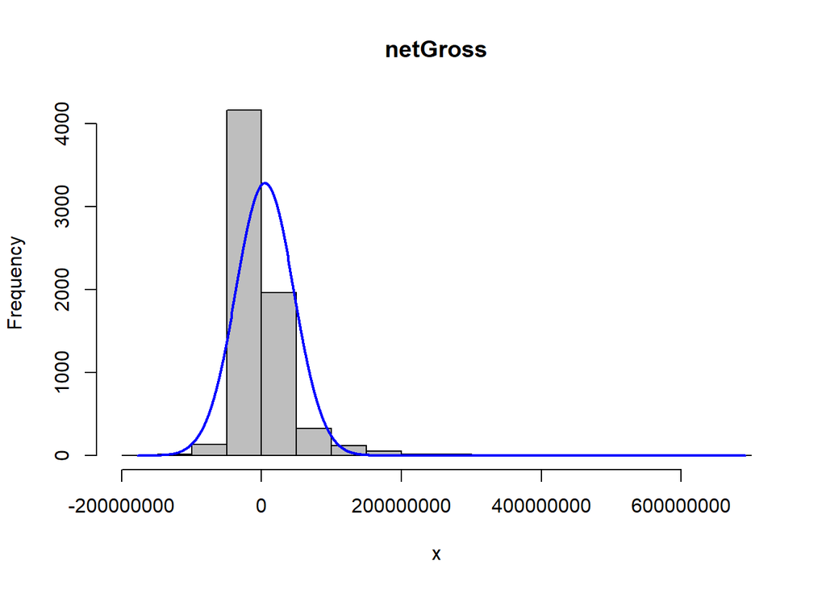

### Beneficio vs budget

El beneficio neto crece a medida que crecen el presupuesto, pero la relación no es muy fuerte, hay que explicarla con más variables que veremos más adelante.

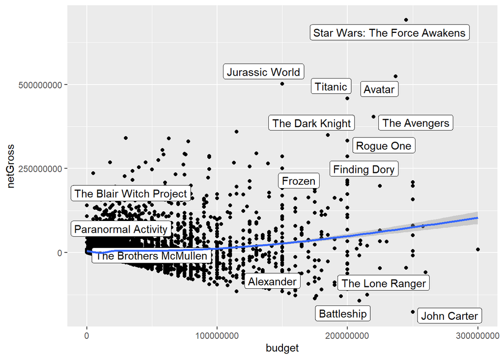

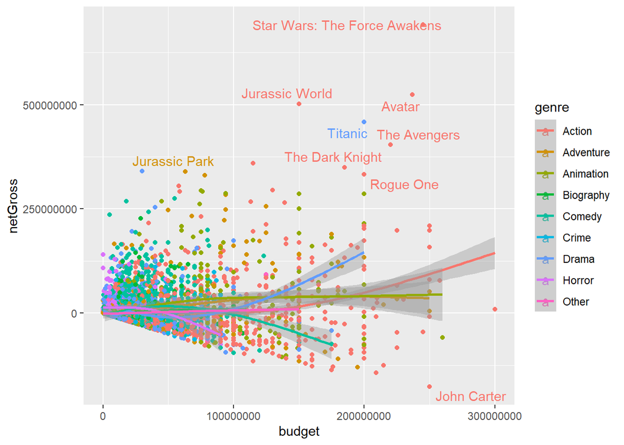

Volvemos a ver el sesgo a la derecha de las variables numéricas que podemos controlar, ya que otras como año, score o votes es algo que no decidimos a priori cuando vamos a producir una película. El beneficio sí está muy relacionado con el presupuesto, pero no tanto el beneficio neto.

## Correlaciones

Antes de ajustar un modelo predictivo, confirmamos que no haya alta correlación entre variables explicativas. El siguiente gráfico de correlaciones muestra la correlación fuerte que hay entre presupuesto y votos, así que es mejor no incluir ambas. Por supuesto, incluimos la que podemos controlar.

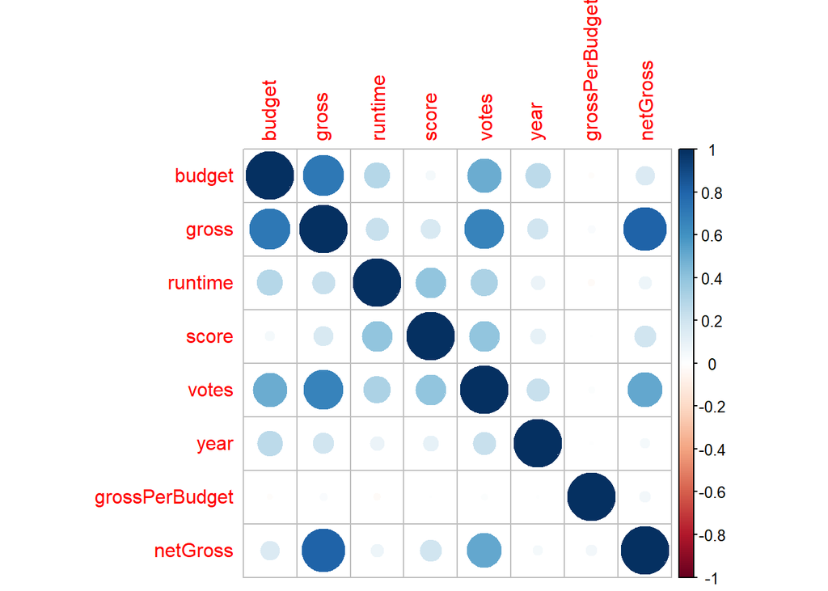

## Modelo explicativo

```
## Analysis of Variance Table
##
## Response: gross
##             Df               Sum Sq              Mean Sq   F value
## budget       1 11679742374635507712 11679742374635507712 7254.1170
## country      4   203275466723035360    50818866680758840   31.5629
## genre        8   131674399780304240    16459299972538030   10.2226
## rating       5    32659905817339696     6531981163467939    4.0569
## runtime      1    99758503213369584    99758503213369584   61.9585
## Residuals 6800 10948575585709309952     1610084644957252
##                          Pr(>F)
## budget    < 0.00000000000000022 ***
## country   < 0.00000000000000022 ***
## genre      0.000000000000026396 ***
## rating                 0.001117 **
## runtime    0.000000000000004054 ***
## Residuals
## ---
## Signif. codes:  0 '***' 0.001 '**' 0.01 '*' 0.05 '.' 0.1 ' ' 1
```

```
##
## Call:
## lm(formula = gross ~ ., data = fit.data)
##
## Residuals:
##        Min         1Q     Median         3Q        Max
## -210752126  -15487424   -4117557    7728220  657301972
##
## Coefficients:
##                       Estimate      Std. Error t value             Pr(>|t|)
## (Intercept)    -24721488.32583   5797461.61339  -4.264  0.00002033424767029 ***
## budget                 1.09173         0.01779  61.378 < 0.0000000000000002 ***
## countryFrance   -7409377.14171   4083588.29929  -1.814              0.06966 .
## countryUK       -1876751.51868   3625163.24183  -0.518              0.60468
## countryUSA       8096879.91830   3344146.82613   2.421              0.01549 *
## countryOther    -5483315.82633   3594101.75491  -1.526              0.12715
## genreAdventure   5970193.46763   2389868.54975   2.498              0.01251 *
## genreAnimation  18455919.60844   3125431.99380   5.905  0.00000000369470877 ***
## genreBiography   1138709.14710   2499652.76068   0.456              0.64873
## genreComedy      6097868.31568   1514769.92786   4.026  0.00005744594653923 ***
## genreCrime        557516.40812   2159771.32718   0.258              0.79631
## genreDrama       -443854.44295   1647049.42214  -0.269              0.78756
## genreHorror     16138137.82974   2729200.60293   5.913  0.00000000351919958 ***
## genreOther       1232977.95373   3632191.89276   0.339              0.73427
## ratingNC-17    -13671005.11223   9385035.98718  -1.457              0.14525
## ratingPG        -4803419.40647   3791032.70741  -1.267              0.20518
## ratingPG-13     -5104098.80331   3883745.63549  -1.314              0.18882
## ratingR        -10634209.67933   3849811.43377  -2.762              0.00576 **
## ratingUNRATED  -10287130.53850   4475000.51380  -2.299              0.02155 *
## runtime           247169.53087     31401.06119   7.871  0.00000000000000405 ***
## ---
## Signif. codes:  0 '***' 0.001 '**' 0.01 '*' 0.05 '.' 0.1 ' ' 1
##
## Residual standard error: 40130000 on 6800 degrees of freedom
## Multiple R-squared:  0.5259, Adjusted R-squared:  0.5246
## F-statistic: 397.1 on 19 and 6800 DF,  p-value: < 0.00000000000000022
```

El análisis de varianza de Anova nos indica que las variables categóricas “country”, “genre” y “rating” son significativas a la hora de explicar el beneficio neto. Veamos cómo afecta cada una mediante una regresión lineal.

### Género

Se ha usado el género de acción como referencia.A partir de este podemos decir que animación es el género que más beneficio da. La interpretación es la siguiente: Hacer una película de animación está significativamente asociado con un incremento promedio de 18 millones comparado con el género acción. El género de terror 16M, y la comedia 6 millones. Por tanto la recomendación es hacer una película de uno de estos géneros.

### Duración

La duración de la película también tiene una relación positiva y significativa, aumentando el beneficio 245k por cada unidad de aumento de la duración, que viene en minutos.

### Rating

En cuanto al rating, el preferible es “G”, mientras que R y UNRATED tienen una correlación negativa con el beneficio neto. En promedio, una película de rating “R” tiene 10M menos de beneficio que una película con rating “G”.

### Presupuesto

Por último, el presupuesto tiene una relación positiva y significativa, aumentando el beneficio neto promedio en 0.09 por cada dolar invertido. Recuperas el dolar invertido más un 9%.

## Predicciones

```r
if(exists('new_data')){rm(new_data)}
new_data=expand.grid(budget = seq(from = 1e+06, to=300e+06, length.out=3 ),
                     country = "USA",
                     genre = c("Action", "Comedy", "Animation", "Drama"),
                     rating = c("G","R"),
                     runtime = 106
                     )
new_data$gross <-  predict(fit, newdata = new_data)
new_data[order(-new_data$gross),]
```

```
##       budget country     genre rating runtime        gross
## 9  300000000     USA Animation      G     106 355550348.11
## 21 300000000     USA Animation      R     106 344916138.43
## 6  300000000     USA    Comedy      G     106 343192296.82
## 3  300000000     USA    Action      G     106 337094428.50
## 12 300000000     USA     Drama      G     106 336650574.06
## 18 300000000     USA    Comedy      R     106 332558087.14
## 15 300000000     USA    Action      R     106 326460218.82
## 24 300000000     USA     Drama      R     106 326016364.38
## 8  150500000     USA Animation      G     106 192336679.90
## 20 150500000     USA Animation      R     106 181702470.22
## 5  150500000     USA    Comedy      G     106 179978628.61
## 2  150500000     USA    Action      G     106 173880760.29
## 11 150500000     USA     Drama      G     106 173436905.85
## 17 150500000     USA    Comedy      R     106 169344418.93
## 14 150500000     USA    Action      R     106 163246550.62
## 23 150500000     USA     Drama      R     106 162802696.17
## 7    1000000     USA Animation      G     106  29123011.69
## 19   1000000     USA Animation      R     106  18488802.02
## 4    1000000     USA    Comedy      G     106  16764960.40
## 1    1000000     USA    Action      G     106  10667092.09
## 10   1000000     USA     Drama      G     106  10223237.64
## 16   1000000     USA    Comedy      R     106   6130750.72
## 13   1000000     USA    Action      R     106     32882.41
## 22   1000000     USA     Drama      R     106   -410972.04
```

### Algunas conclusiones

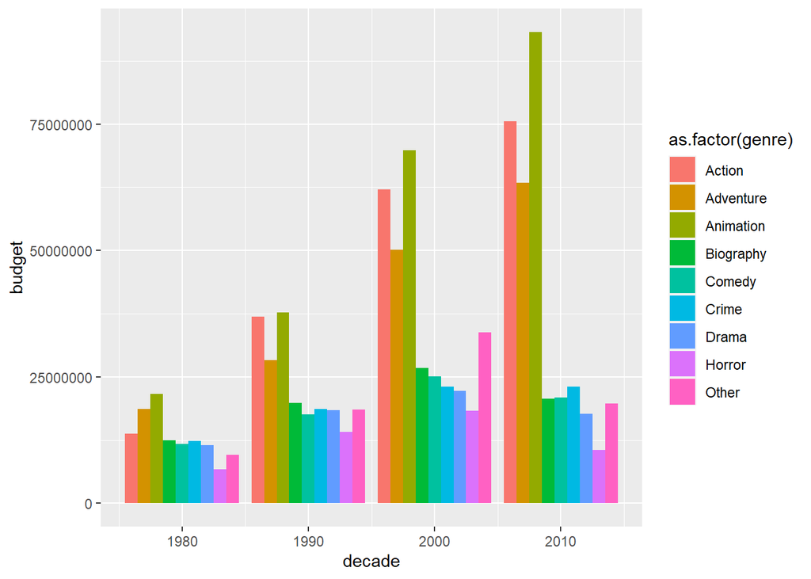

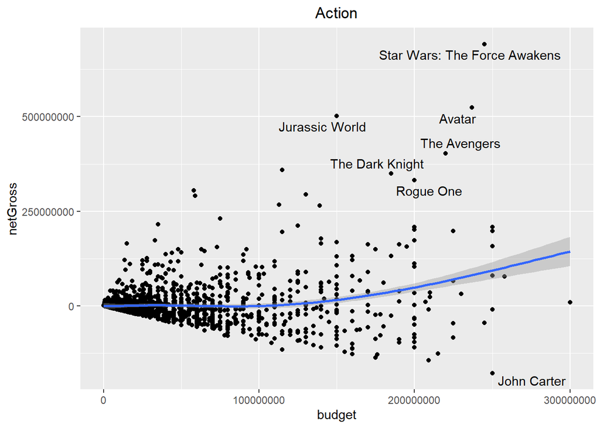

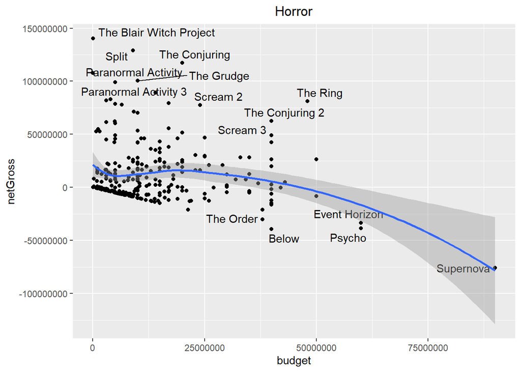

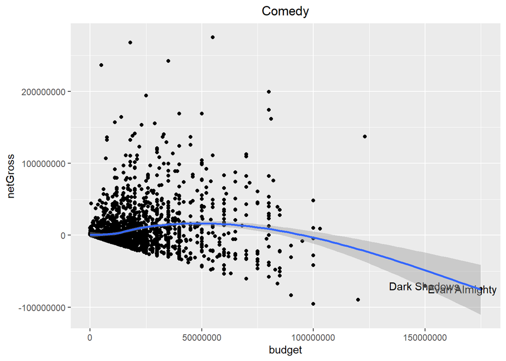

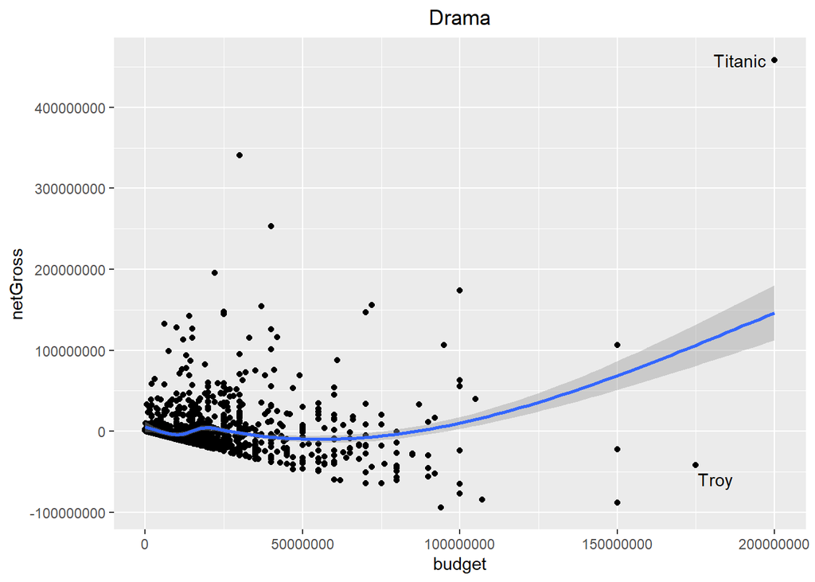